# Many Types of Predictors Homework

#### Multiple Linear Regression

Loading in the data

```r
# Libraries
library(tidyverse)
```

```r
library(ggplot2)
library(performance)
library(modelr)
library(visdat)
library(skimr)
library(GGally)
library(car)
library(broom)
library(visreg)
library(emmeans)
rikz <- read_csv("https://biol607.github.io/homework/data/rikz.csv")
```

```
## ──────────────────────────────────────────────────────── Delimiter: "," dbl
## (16): ...1, Sample, week, angle1, angle2, exposure, salinity, temperatur...
```

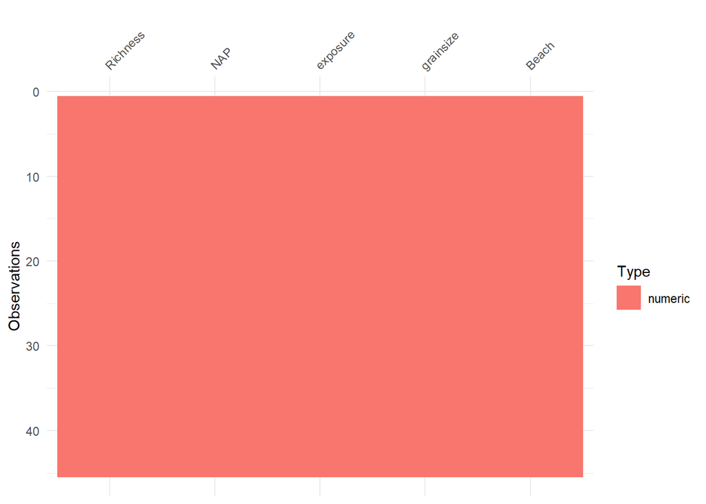

```r
# selecting variables
rikz <- rikz|>
  select(Richness, NAP, exposure, grainsize, Beach)
vis_dat(rikz)
```

```r
skim(rikz)
```

Data summary

| Name | rikz |
| --- | --- |
| Number of rows | 45 |
| Number of columns | 5 |
| _______________________ |  |
| Column type frequency: |  |
| numeric | 5 |
| ________________________ |  |
| Group variables | None |

**Variable type: numeric**

| skim_variable | n_missing | complete_rate | mean | sd | p0 | p25 | p50 | p75 | p100 | hist |
| --- | --- | --- | --- | --- | --- | --- | --- | --- | --- | --- |
| Richness | 0 | 1 | 5.69 | 5.00 | 0.00 | 3.00 | 4.00 | 8.00 | 22.00 | ▇▃▂▁▁ |
| NAP | 0 | 1 | 0.35 | 0.99 | -1.34 | -0.38 | 0.17 | 1.12 | 2.26 | ▅▇▅▅▃ |
| exposure | 0 | 1 | 10.22 | 0.93 | 8.00 | 10.00 | 10.00 | 11.00 | 11.00 | ▂▁▁▇▇ |
| grainsize | 0 | 1 | 272.46 | 57.89 | 186.00 | 222.50 | 266.00 | 316.50 | 405.50 | ▇▇▆▆▁ |
| Beach | 0 | 1 | 5.00 | 2.61 | 1.00 | 3.00 | 5.00 | 7.00 | 9.00 | ▇▇▃▇▇ |

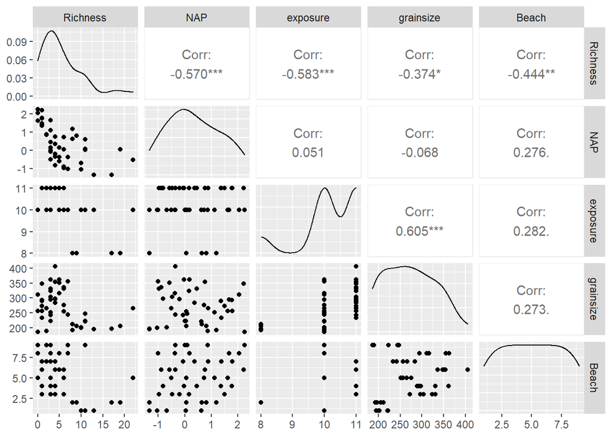

```r
ggpairs(rikz)
```

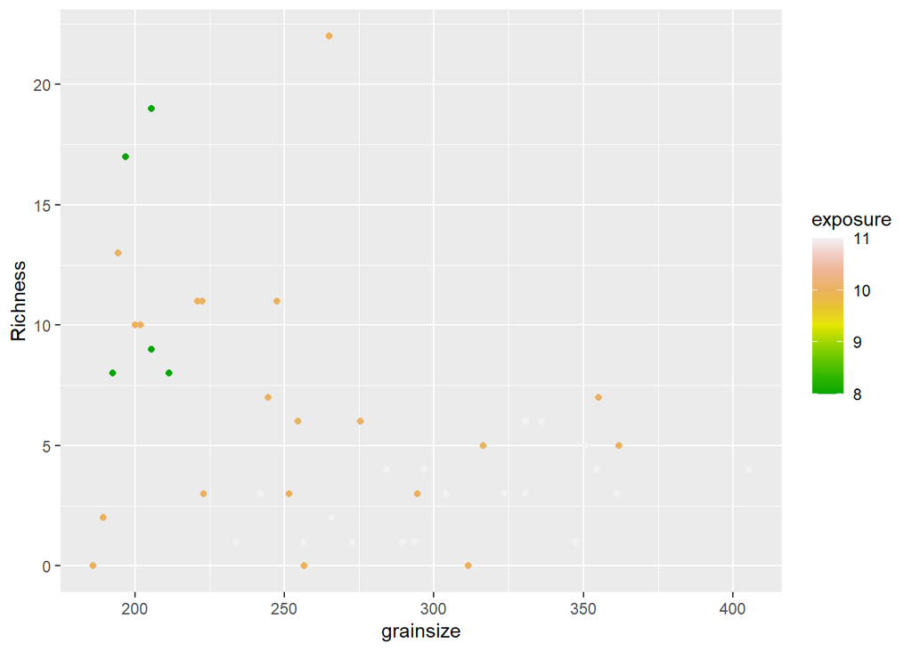

```r
ggplot(data = rikz, mapping = aes(x = grainsize,
                                  y = Richness,
                                  color = exposure))+
  geom_point() +
  scale_color_gradientn(colours = terrain.colors(10))
```

It looks as if the data is cool to proceed.

Modeling richness as a function of exposure, grainsize, NAP. Evaluating assumptions and transforming if necessary.

```r
# Building the model
rikz_lm <- lm(formula = Richness ~ NAP + exposure + grainsize, data = rikz)
rikz_lm
```

```
##
## Call:
## lm(formula = Richness ~ NAP + exposure + grainsize, data = rikz)
##
## Coefficients:
## (Intercept)          NAP     exposure    grainsize
##     36.0963      -2.7852      -2.6027      -0.0104
```

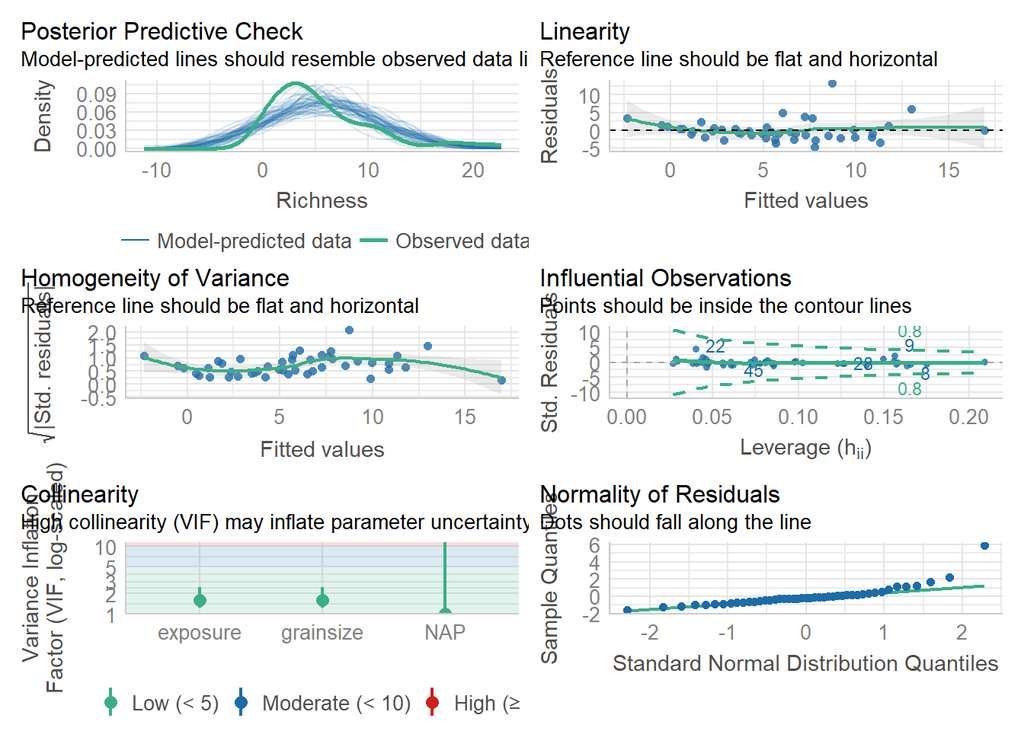

```r
# Assumptions?
check_model(rikz_lm)
```

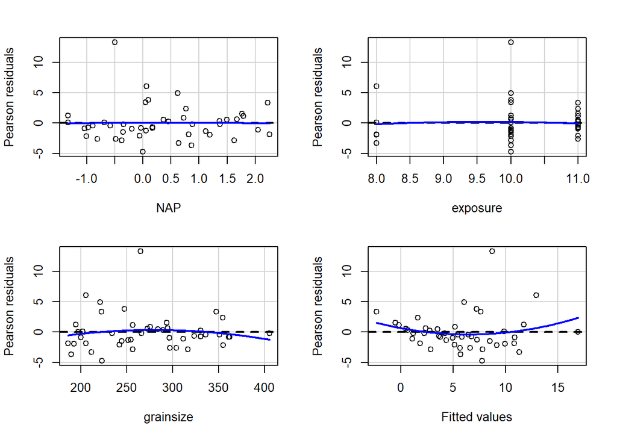

```
##            Test stat Pr(>|Test stat|)
## NAP          -0.0630           0.9501
## exposure     -0.3090           0.7590
## grainsize    -0.7783           0.4410
## Tukey test    1.2656           0.2057
```

```r
# checking each predictor for residuals
residualPlots(rikz_lm)
```

```r
# what does the model mean
tidy(rikz_lm)
```

```
## # A tibble: 4 × 5
##   term        estimate std.error statistic      p.value
##   <chr>          <dbl>     <dbl>     <dbl>        <dbl>
## 1 (Intercept)  36.1       5.32        6.79 0.0000000328
## 2 NAP          -2.79      0.475      -5.86 0.000000678
## 3 exposure     -2.60      0.638      -4.08 0.000205
## 4 grainsize    -0.0104    0.0102     -1.02 0.315
```

```r
r2(rikz_lm)
```

```
## # R2 for Linear Regression
##        R2: 0.641
##   adj. R2: 0.615
```

I think this model looks pretty good and won’t need any transformations.

Plotting individual contributions of each predictor

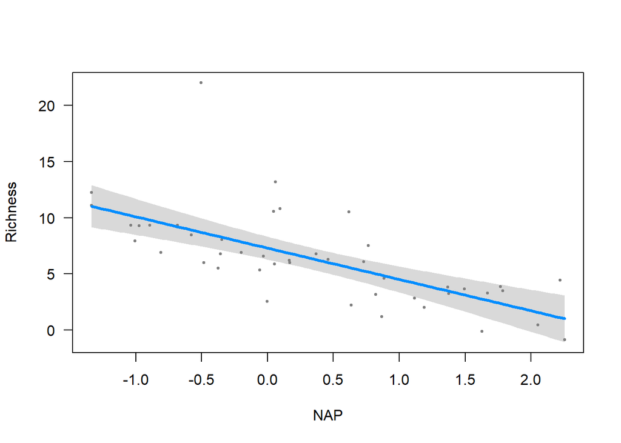

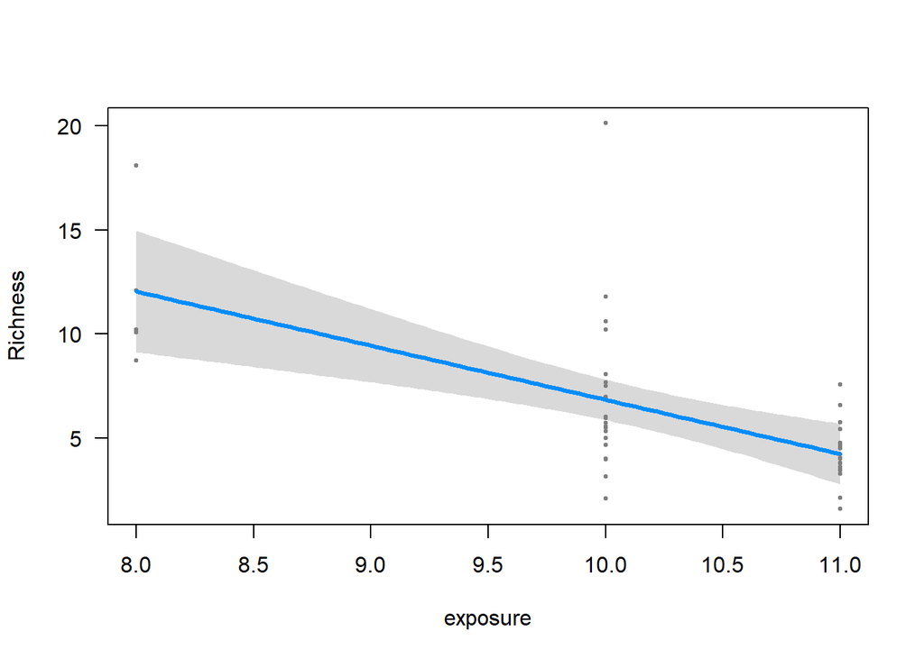

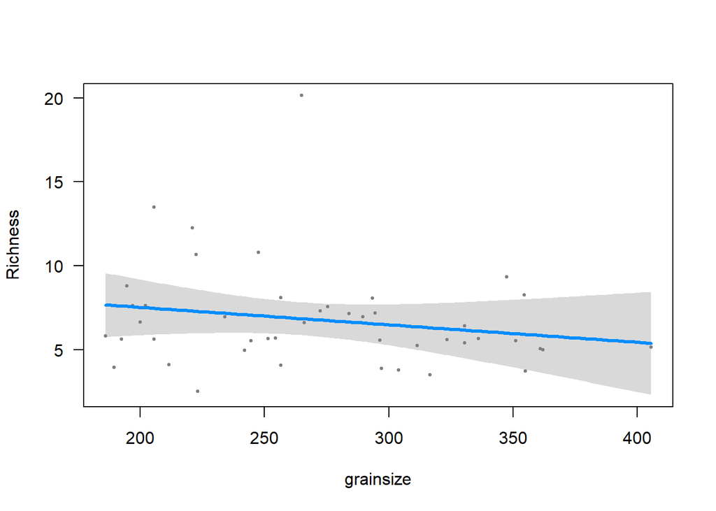

```r
#evaluating each predictor when others are at their mean
visreg(rikz_lm)
```

Constructing a cool viz for the data

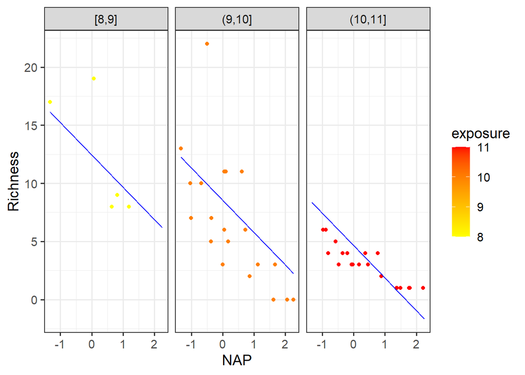

```r
# Getting the CI
rikz_pred <- data_grid(rikz,
                       NAP = seq_range(NAP, 100),
                       exposure = seq_range(exposure, 3),
                       grainsize = mean(grainsize))|>
  augment(rikz_lm, newdata = _, interval = "confidence")|>
  rename(Richness = .fitted)

# Plotting
ggplot(data = rikz,
       mapping = aes(x = NAP,
                     y = Richness,
                     color = exposure)) +
  geom_point() +
  geom_line(data = rikz_pred, aes(group = exposure, y =  Richness), color = 'blue') +
  # geom_ribbon(data = rikz_pred,
  #             aes(group = exposure, ymin = .lower, ymax = .upper),
  #             color = "lightgrey", alpha = 0.2) +
  scale_color_gradient(low="yellow", high="red")+
  facet_wrap(vars(cut_interval(exposure, 3)))+
  theme_bw(base_size = 14)
```

#### Multiple Categorical Variables

Loading in the data, filtering out NA in sex and making sure year is not continuous. Vizzing as well.

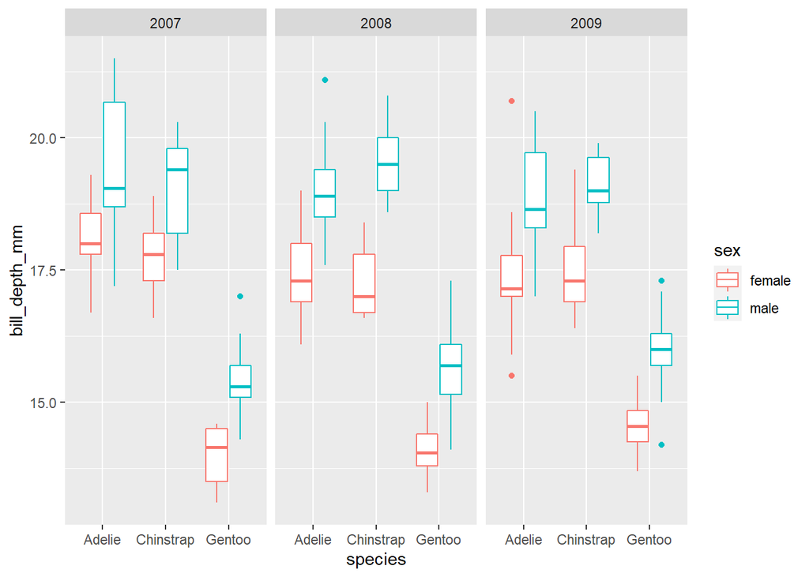

```r
# Loading
library(palmerpenguins)
peng <- penguins

# No NA in sex and year as factor
peng <- peng |>
  filter(!is.na(sex))|>
  mutate(year = as.factor(year))

# vizzing
ggplot(peng, mapping = aes(x = species,
                           y = bill_depth_mm,
                           color = sex))+
  geom_boxplot()+
  facet_grid(cols = vars(year))
```

It looks cool! Without knowing I would say that males seem to have a higher bill_depth than females, while Gentoos have smaller compared to other species but getting bigger as time moves on.

Modeling

```r
peng_lm <- lm(formula = bill_depth_mm ~ species + sex + year,
              data = peng)
tidy(peng_lm)
```

```
## # A tibble: 6 × 5
##   term             estimate std.error statistic   p.value
##   <chr>               <dbl>     <dbl>     <dbl>     <dbl>
## 1 (Intercept)       17.7       0.108    165.    1.23e-316
## 2 speciesChinstrap   0.0565    0.122      0.462 6.44e-  1
## 3 speciesGentoo     -3.36      0.103    -32.8   2.66e-105
## 4 sexmale            1.50      0.0911    16.5   5.18e- 45
## 5 year2008          -0.211     0.114     -1.85  6.51e-  2
## 6 year2009          -0.144     0.112     -1.28  2.01e-  1
```

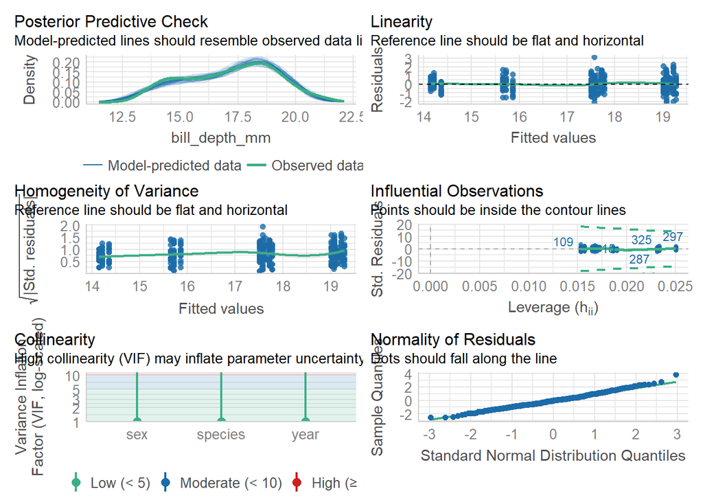

```r
# Checking the model
check_model(peng_lm)
```

This looks good. Especially linearity as the line is flat and horizontal. But we can explore it more.

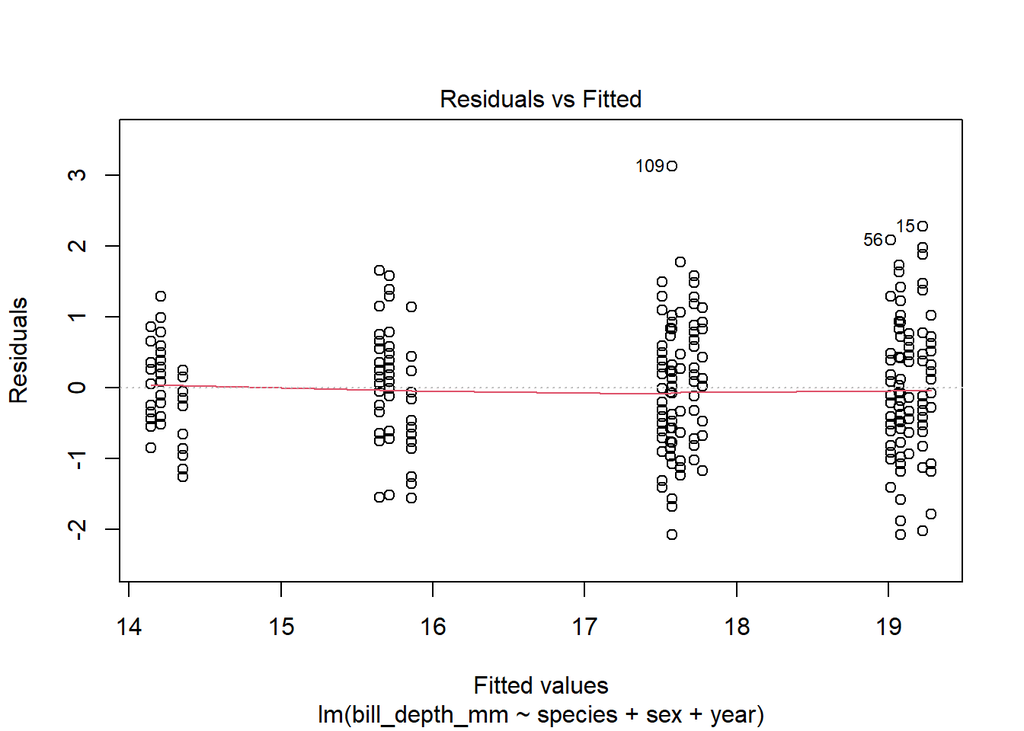

```r
# linearity
plot(peng_lm, which = 1)
```

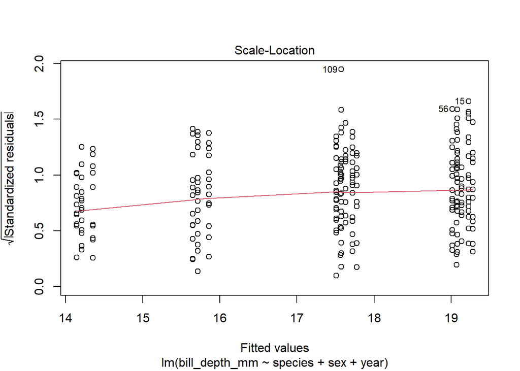

```r
#HOV
plot(peng_lm, which = 3)
```

I still think these work and will continue.

What does this model mean:

Well, Female Adelie penguins’ bill_depth_mm in 2007 were 17.7. Bill_depth_mm goes up 0.056 when species changes to chinstrap. Bill depth goes down 3.36 when species switches to Gentoo. When sex switches to male the bill depth increases 1.5. When the year increases to 2008 bill depth goes down .21 and finally when year goes to 2009 bill depth decreases 0.14.

Peeking at the Emmeans

```r
peng_em_sp <- emmeans(peng_lm, ~ species)
peng_em_sp |>
  contrast(method = 'pairwise')|>
  confint()
```

```
##  contrast           estimate    SE  df lower.CL upper.CL
##  Adelie - Chinstrap  -0.0565 0.122 327   -0.344    0.231
##  Adelie - Gentoo      3.3638 0.103 327    3.122    3.605
##  Chinstrap - Gentoo   3.4202 0.127 327    3.121    3.719
##
## Results are averaged over the levels of: sex, year
## Confidence level used: 0.95
## Conf-level adjustment: tukey method for comparing a family of 3 estimates
```

```r
peng_em_se <- emmeans(peng_lm, ~ sex)
peng_em_se |>
  contrast(method = 'pairwise')|>
  confint()
```

```
##  contrast      estimate     SE  df lower.CL upper.CL
##  female - male     -1.5 0.0911 327    -1.68    -1.33
##
## Results are averaged over the levels of: species, year
## Confidence level used: 0.95
```

```r
peng_em_yr <- emmeans(peng_lm, ~ year)
peng_em_yr |>
  contrast(method = 'pairwise')|>
  confint()
```

```
##  contrast            estimate    SE  df lower.CL upper.CL
##  year2007 - year2008   0.2105 0.114 327  -0.0573    0.478
##  year2007 - year2009   0.1442 0.112 327  -0.1205    0.409
##  year2008 - year2009  -0.0664 0.110 327  -0.3248    0.192
##
## Results are averaged over the levels of: species, sex
## Confidence level used: 0.95
## Conf-level adjustment: tukey method for comparing a family of 3 estimates
```

It looks like sex and species are effecting the bill depth length the most.

Vizzing

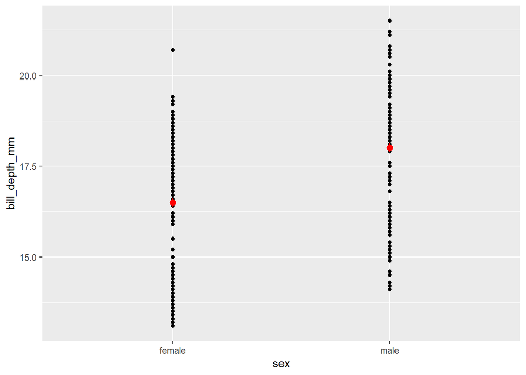

```r
# Plotting
peng_em_se_plot <- peng_em_se |>
  confint() |>
  as_tibble()

peng_plot_sex <- ggplot(data = peng,
                    aes(x = sex, y = bill_depth_mm)) +
  geom_point()

peng_plot_sex +
  geom_pointrange(data = peng_em_se_plot,
                  aes(y = emmean,
                      ymin = lower.CL,
                      ymax = upper.CL),
                  color = "red")
```

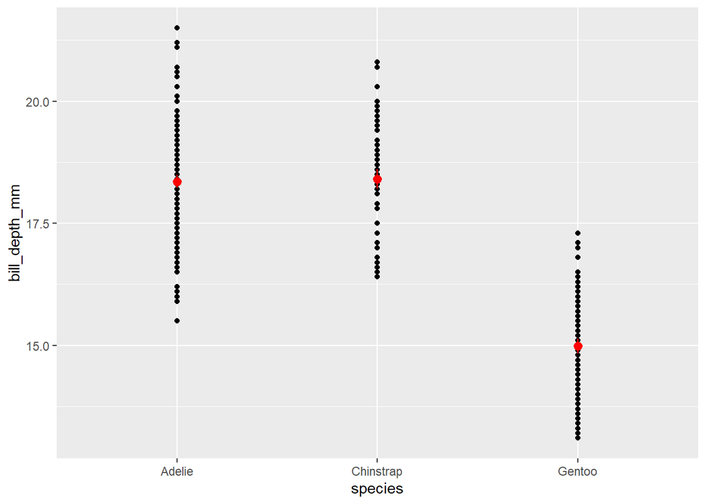

```r
# For species
peng_em_sp_plot <- peng_em_sp |>
  confint() |>
  as_tibble()

peng_plot_species <- ggplot(data = peng,
                    aes(x = species, y = bill_depth_mm)) +
  geom_point()

peng_plot_species +
  geom_pointrange(data = peng_em_sp_plot,
                  aes(y = emmean,
                      ymin = lower.CL,
                      ymax = upper.CL),
                  color = "red")
```

## Comparing Means with Covariates

Data and plotting

```r
# Loading data
caste <- read_csv('https://www.zoology.ubc.ca/~whitlock/ABD/teaching/datasets/18/18e4MoleRatLayabouts.csv')
```

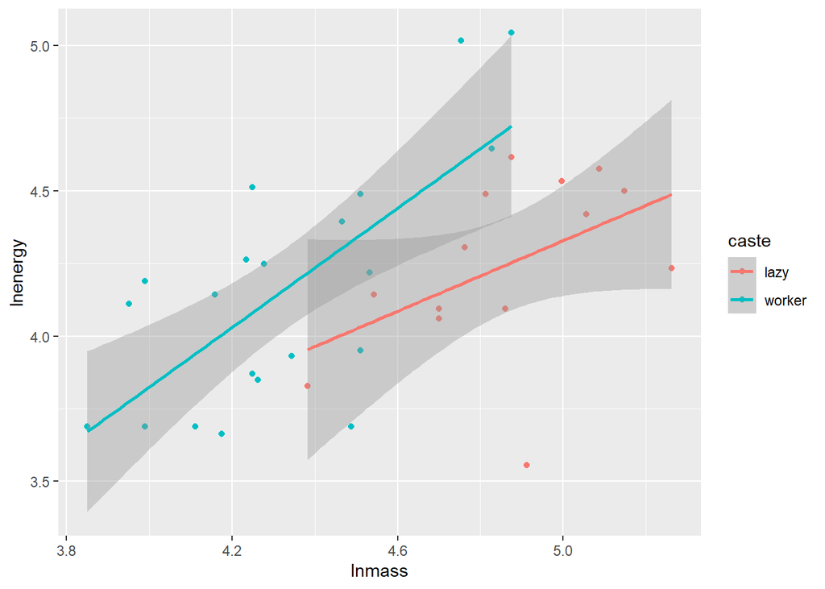

```r
qplot(lnmass, lnenergy, color = caste, data = caste)+
  stat_smooth(method = 'lm')
```

It seems like the covariate of lnmass could be effecting the lnenergy as these lines may not be parallel.

Fitting a model and testing assumptions

```r
# Model
caste_lm <- lm(formula = lnenergy ~ lnmass + caste, data = caste)
tidy(caste_lm)
```

```
## # A tibble: 3 × 5
##   term        estimate std.error statistic   p.value
##   <chr>          <dbl>     <dbl>     <dbl>     <dbl>
## 1 (Intercept)  -0.0969     0.942    -0.103 0.919
## 2 lnmass        0.893      0.193     4.63  0.0000589
## 3 casteworker   0.393      0.146     2.69  0.0112
```

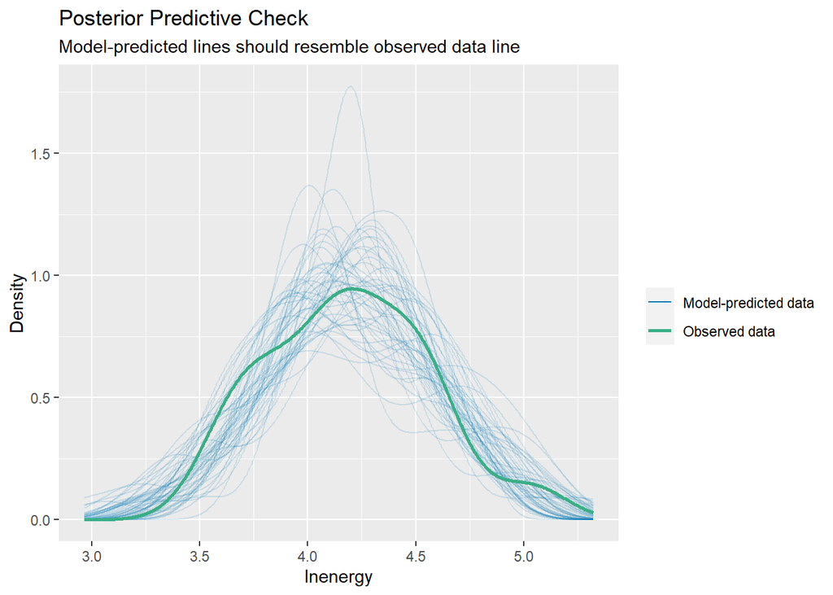

```r
# Assumptions
#checking predictions
check_predictions(caste_lm) |> plot()
```

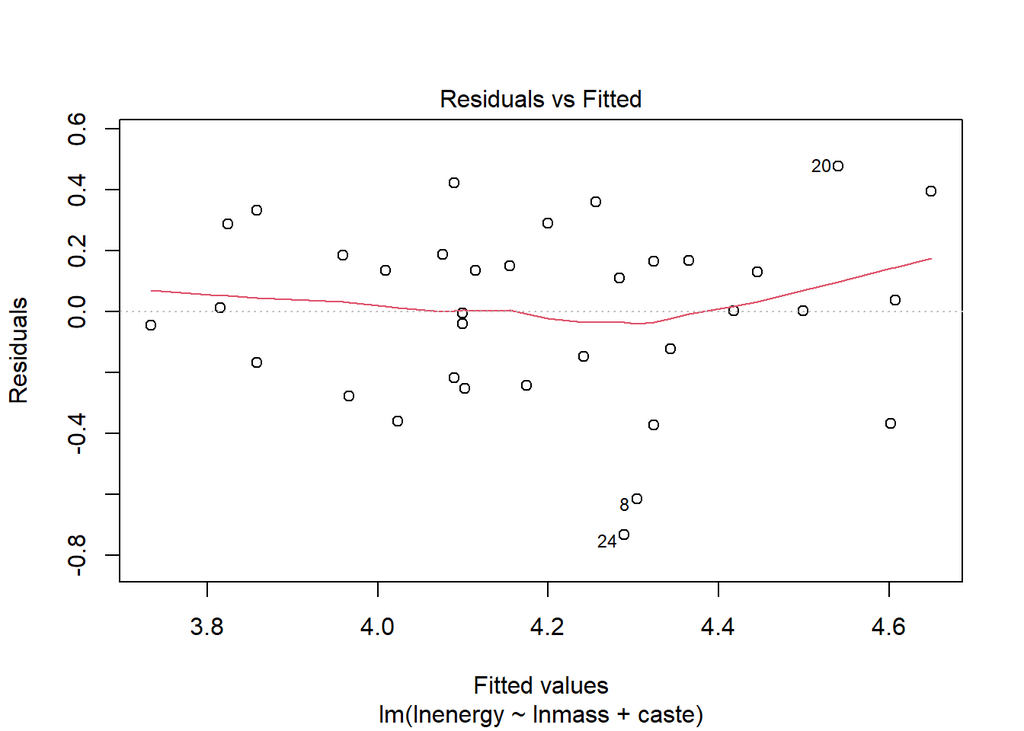

```r
# checking linearity
plot(caste_lm, which = 1)
```

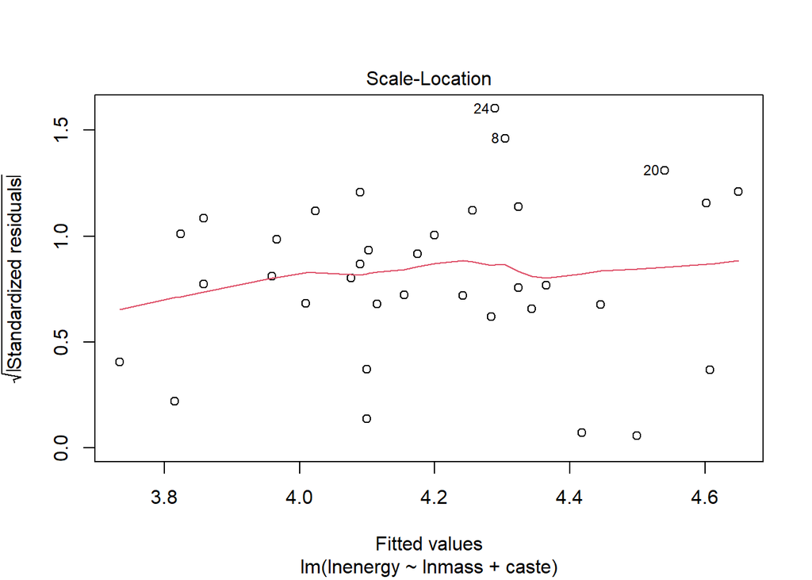

```r
# Checking HOV
plot(caste_lm, which = 3)
```

```
## For confidence bands, please install `qqplotr`.
```

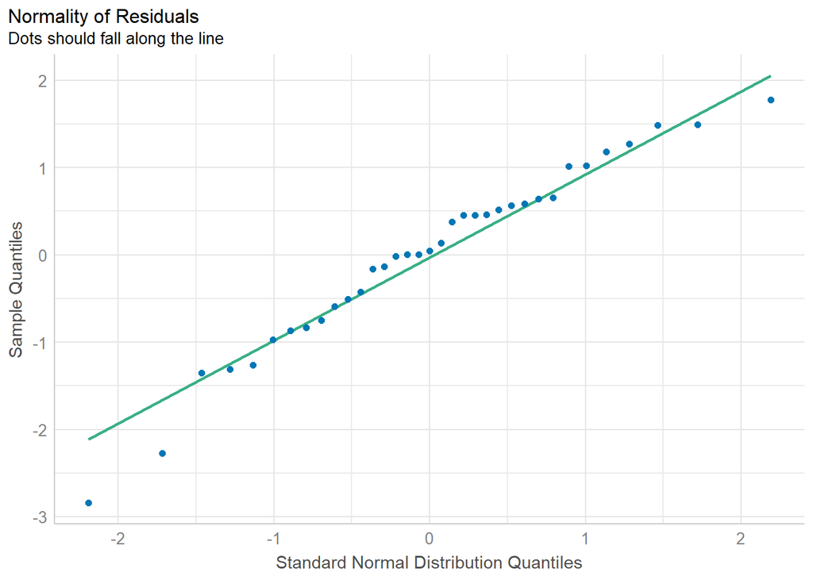

```r
# Checking normality
check_normality(caste_lm) |> plot(type = "qq")
```

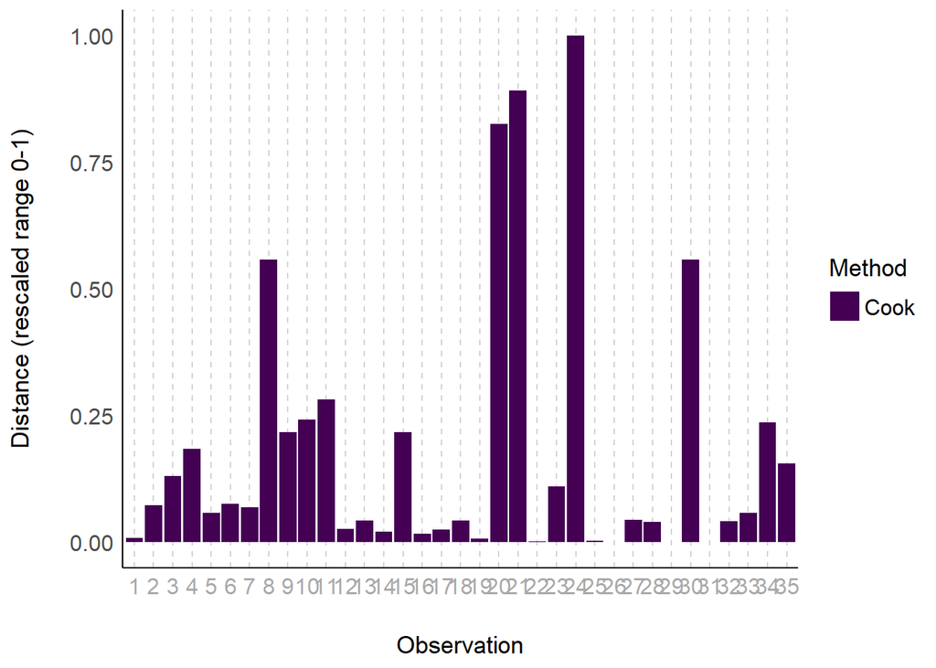

```r
# Checking outliers
check_outliers(caste_lm) |> plot(type = "bar")
```

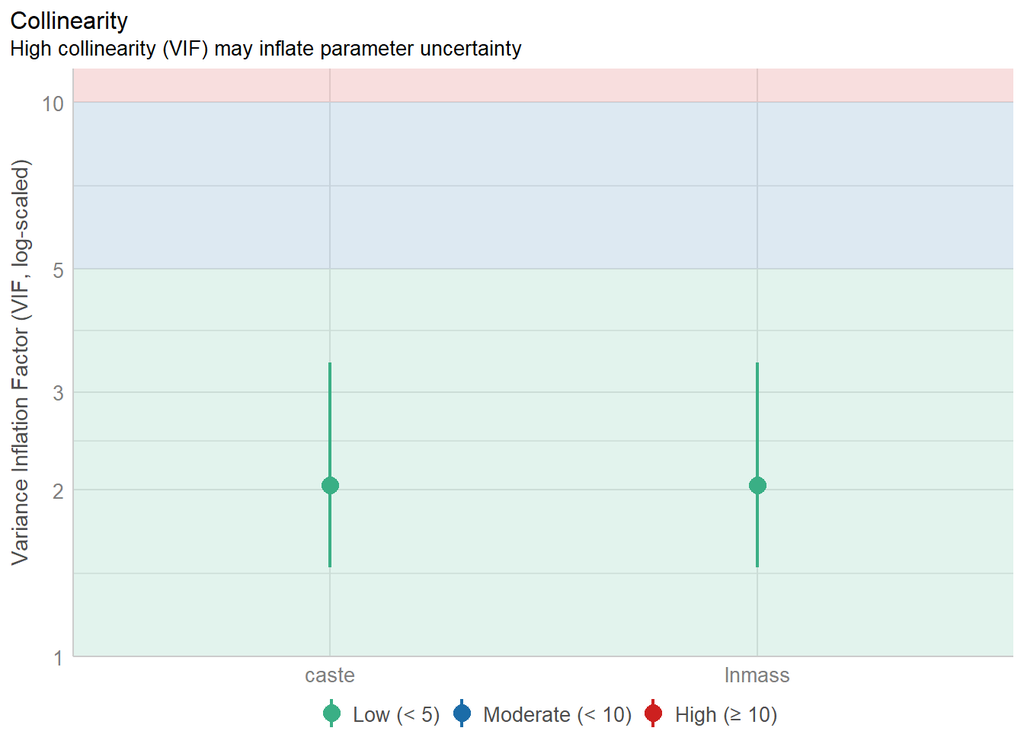

```r
# Checking VIF
check_collinearity(caste_lm) |> plot()
```

We are checking collinearity and it seems to pass every assumption in my opinion.

Checking the mean when mass is at the mean.

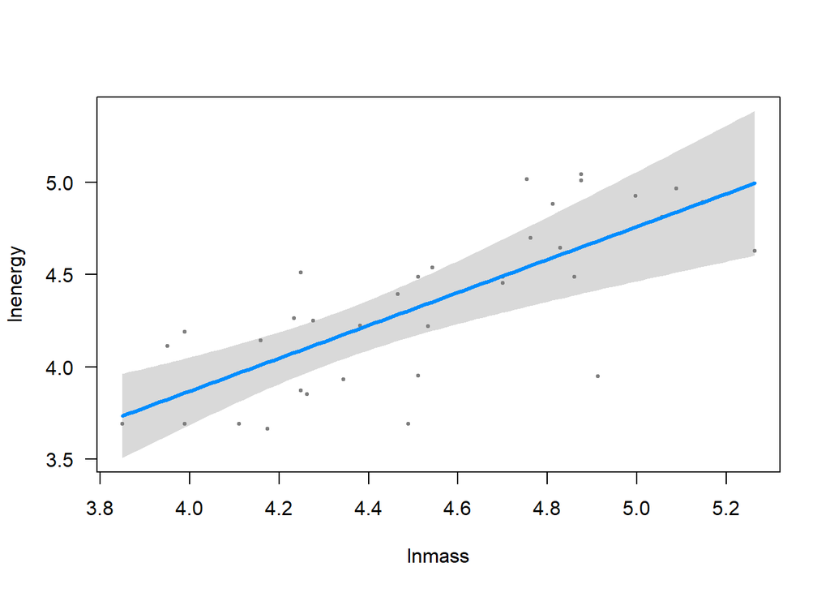

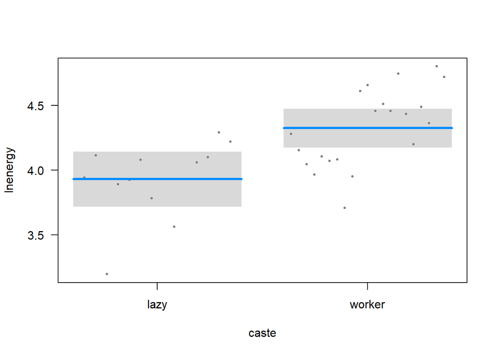

```r
visreg(caste_lm)
```

They appear different to me. This would suggest that workers use more energy than lazy mole rats which makes sense.

Taking a look at emmeans

```r
avg_lnmass_em <- emmeans(caste_lm, ~ caste|lnmass)
avg_lnmass_em
```

```
## lnmass = 4.54:
##  caste  emmean    SE df lower.CL upper.CL
##  lazy     3.96 0.101 32     3.75     4.16
##  worker   4.35 0.077 32     4.19     4.51
##
## Confidence level used: 0.95
```

```r
contrast(avg_lnmass_em, method = 'pairwise')|>
  confint()
```

```
## lnmass = 4.54:
##  contrast      estimate    SE df lower.CL upper.CL
##  lazy - worker   -0.393 0.146 32   -0.691  -0.0957
##
## Confidence level used: 0.95
```

Fitting the model

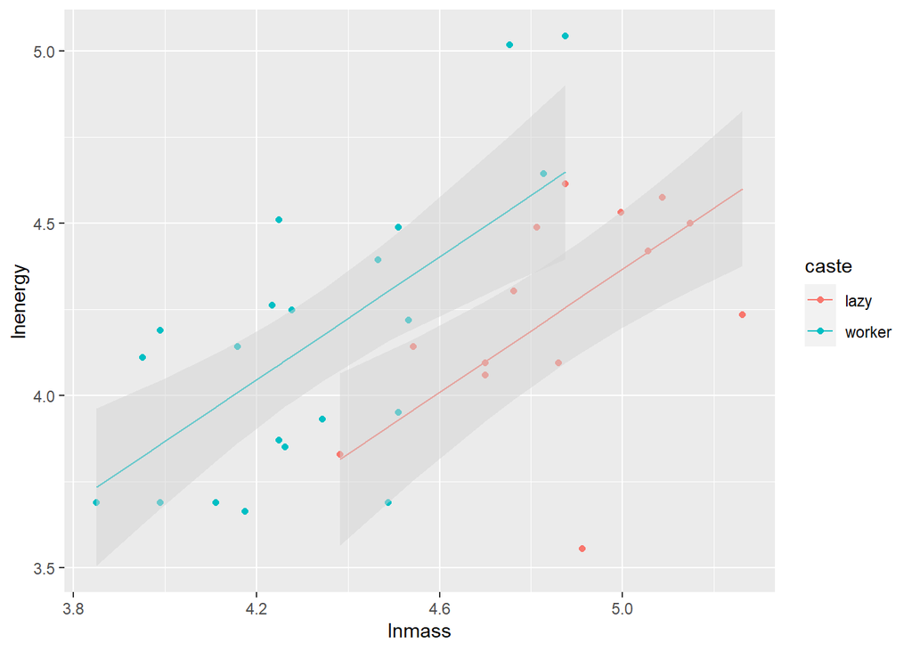

```r
caste_pred <- augment(caste_lm, interval = 'confidence')


# Plotting

ggplot(data = caste_pred, mapping = aes(x = lnmass, color = caste))+
  geom_point(mapping = aes(y = lnenergy))+
  geom_line(mapping = aes(y = .fitted))+
  geom_ribbon(mapping = aes(ymin = .lower,
                            ymax = .upper,
                            group = caste),
              fill = "lightgrey",
              alpha = 0.5,
              color = NA)
```

Meta 1: I think from here we will go to generalized linear models or perhaps inferential statistics. So two way anovas with and without interactions. I think the next homework is interactions.

Meta 2: I think models like these will be interesting in my work as I have data without interaction but has two predictors. So I think this weeks homework directly relates to that data. It is a comparison in the gene expression of one type of ncRNA after rat pups got different housing environments and/or different treatments to induce stress.

Meta 3: I think the hardest thing for me to understand is the prediction model. I think it is a way to query the model for made up data but it is hard for me to create/visualize it in my head.

Meta 4: This roughly took me around 4 hours to complete perhaps 5.

Meta 5: I feel strong in this assignment. Especially with the first one and the last one. I like categorical variables more than continuous. Perhaps thats why I am a behavioral Neuroscientist.